# CMPINF 2130 Summer 2021 - Week 08

Let’s first look at the `ggpairs()` of the continuous variables only.

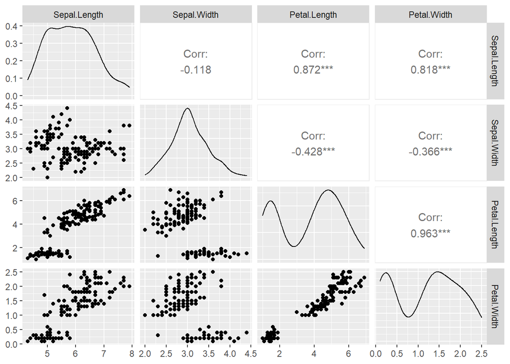

```r
iris %>%
  purrr::keep(is.numeric) %>%
  ggpairs()
```

Let’s hide the progress by setting `progress = FALSE` in the `ggpairs()` call.

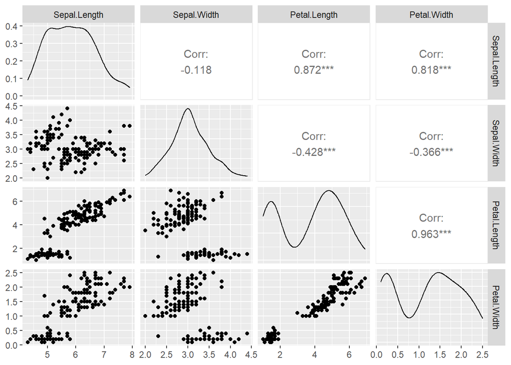

```r
iris %>%
  purrr::keep(is.numeric) %>%
  ggpairs(progress = FALSE)
```

`ggpairs()` produces a ggplot object, so we can set the theme just like we did with “regular” ggplot objects.

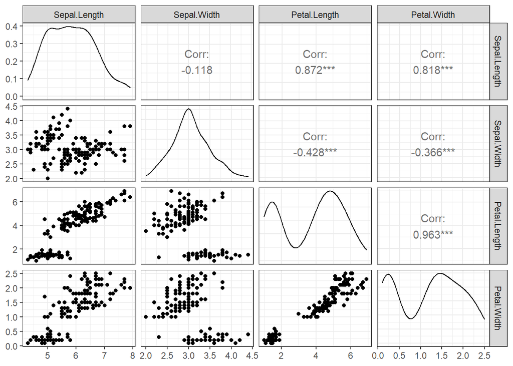

```r
iris %>%
  purrr::keep(is.numeric) %>%
  ggpairs(progress = FALSE) +
  theme_bw()
```

We can use a histogram for the main diagonal instead of the kernel destiny estimate.

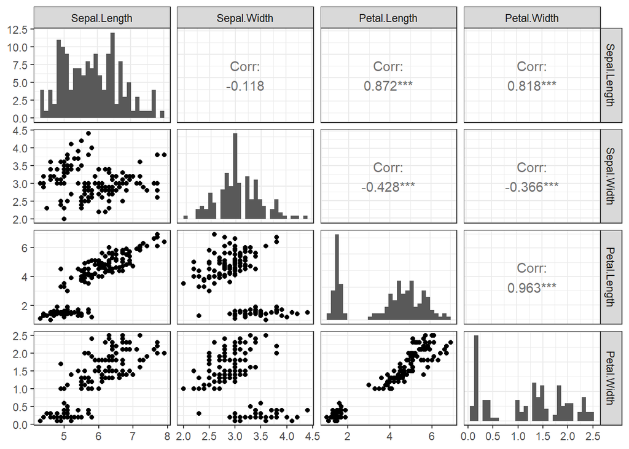

```r
iris %>%
  purrr::keep(is.numeric) %>%
  ggpairs(progress = FALSE,
          diag = list(continuous = 'barDiag')) +
  theme_bw()
```

We can specify the number of bins for the marginal histograms.

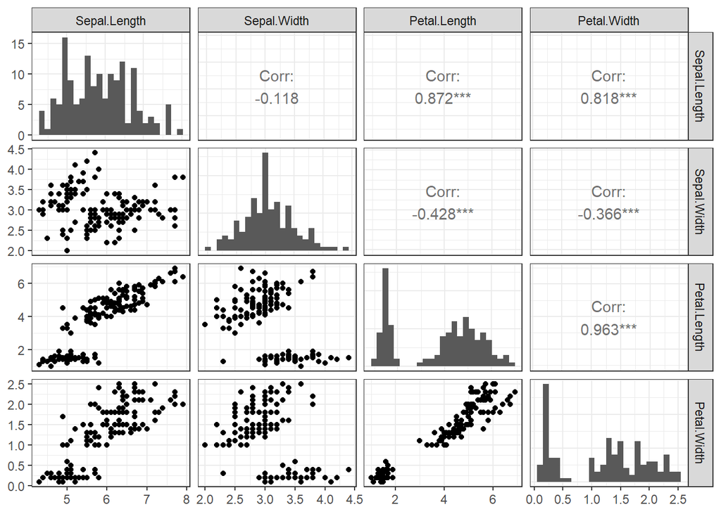

```r
iris %>%
  purrr::keep(is.numeric) %>%
  ggpairs(progress = FALSE,
          diag = list(continuous = wrap('barDiag', bins=25))) +
  theme_bw()
```

We can use the `columns` argument in `ggpairs()` to specify the columns/variables to display.

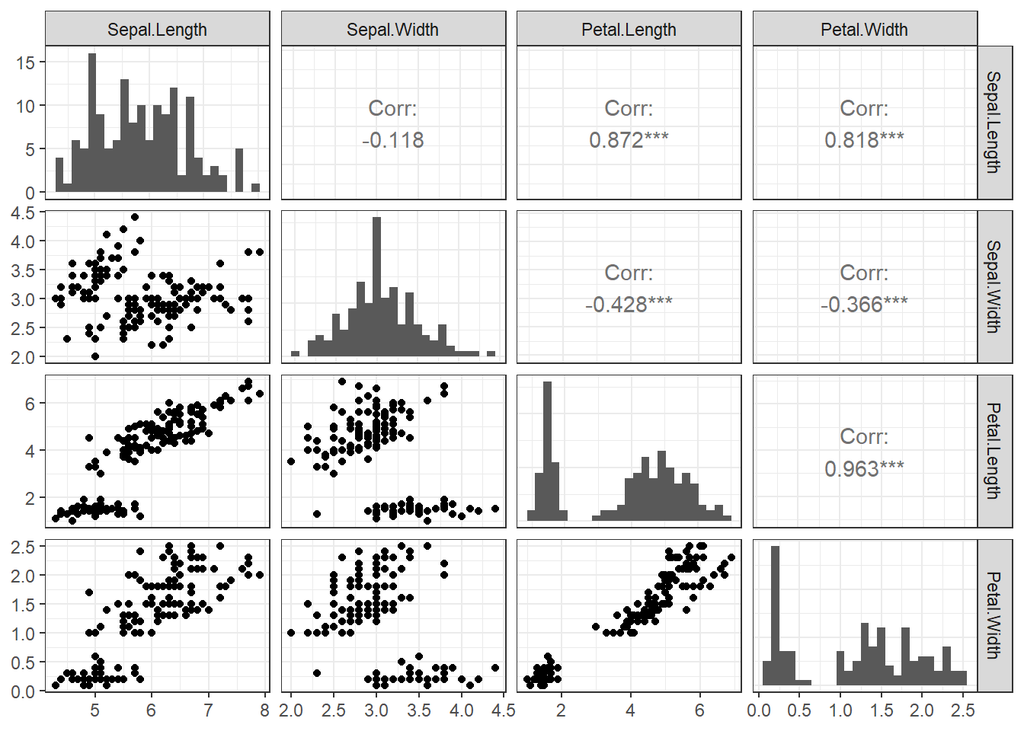

```r
iris %>%
  ggpairs(columns = 1:4,
          progress = FALSE,
          diag = list(continuous = wrap('barDiag', bins=25))) +
  theme_bw()
```

We must know the order of the variables to use the `columns` argument.

```r
iris %>% names()
```

```
## [1] "Sepal.Length" "Sepal.Width"  "Petal.Length" "Petal.Width"  "Species"
```

We can always look at the scatter plot directly to check.

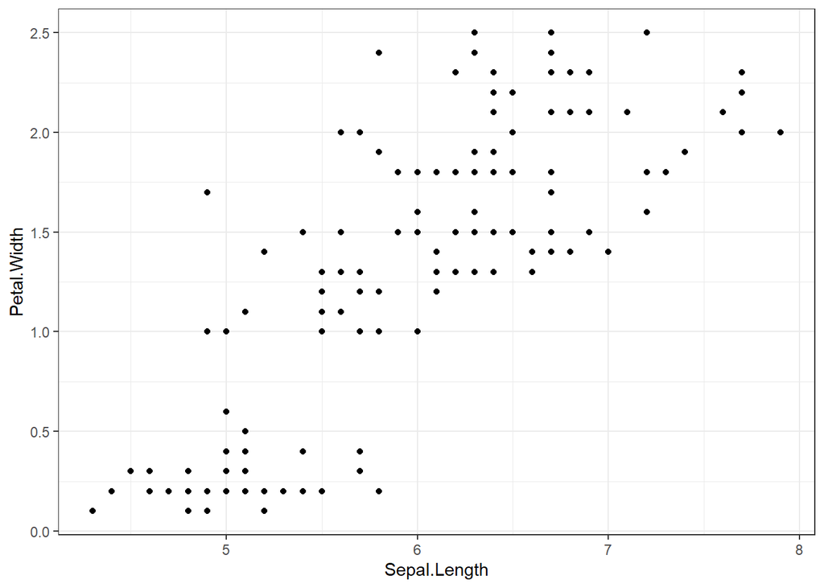

```r
iris %>%
  ggplot(mapping = aes(x = Sepal.Length, y = Petal.Width)) +
  geom_point() +
  theme_bw()
```

`ggpairs()` also works with categorical variables.

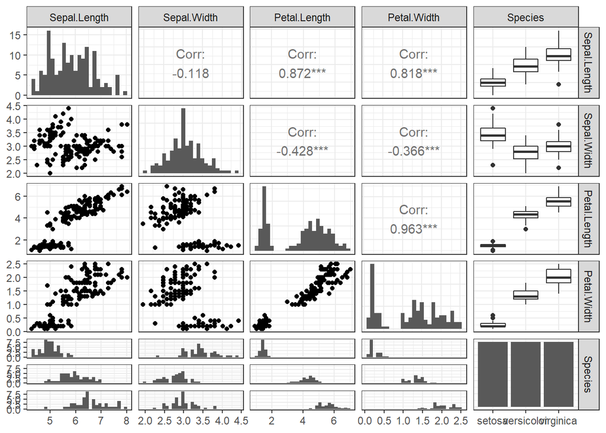

```r
iris %>%
  ggpairs(progress = FALSE,
          diag = list(continuous = wrap('barDiag', bins=25))) +
  theme_bw()
```

We can use stripplots for the lower diagonal for the “combination” between continuous and categorical to be consistent with the continuous scatter plots.

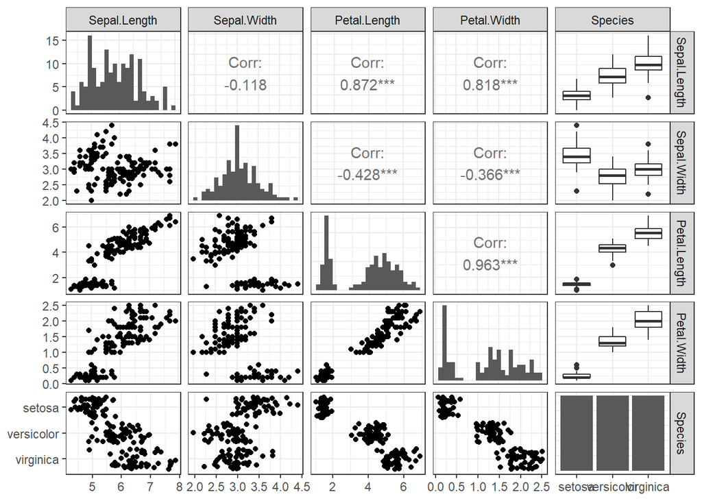

```r
iris %>%
  ggpairs(progress = FALSE,
          diag = list(continuous = wrap('barDiag', bins=25)),
          lower = list(combo = 'dot_no_facet')) +
  theme_bw()
```

Usually when I work with pairs plots I color by a categorical rather than include it in the subplots.

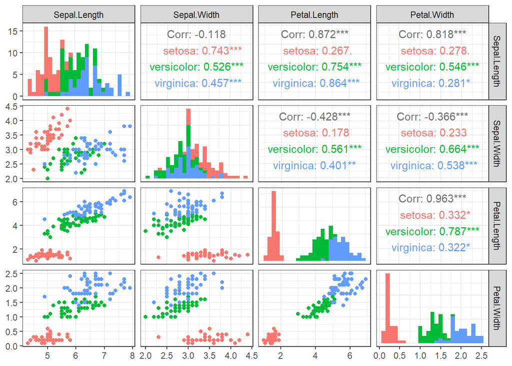

```r
iris %>%
  ggpairs(columns = 1:4,
          progress = FALSE,
          diag = list(continuous = wrap('barDiag', bins=25)),
          mapping = aes(color = Species)) +
  theme_bw()
```

If we do not specify the `diag` we will get the default density plots along the main diagonal.

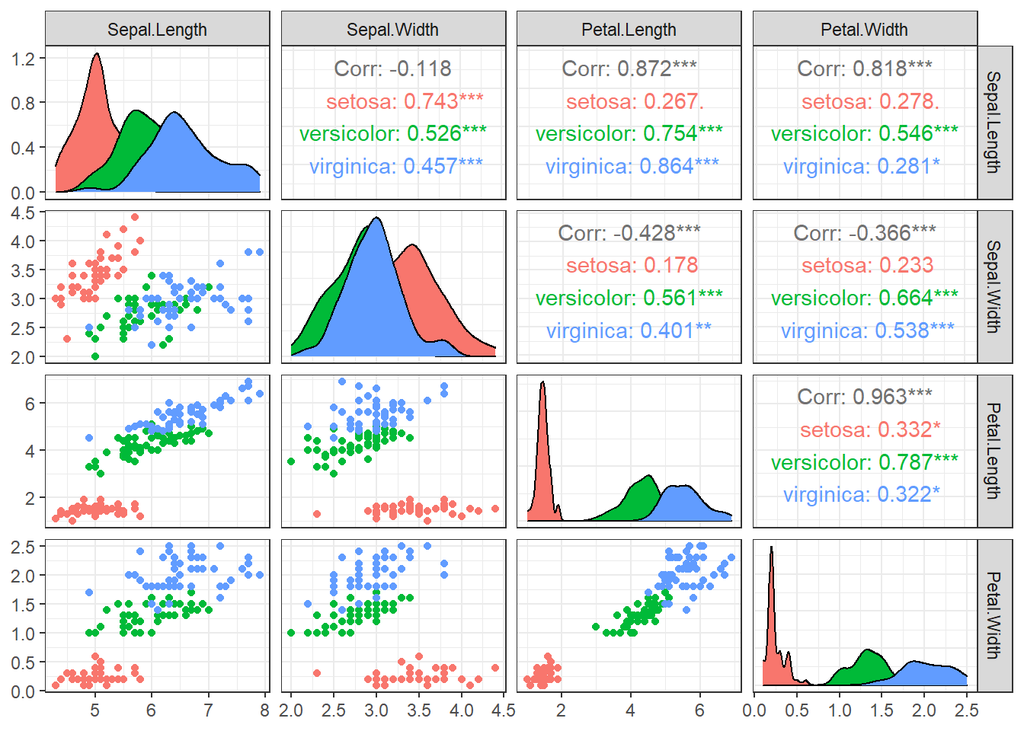

```r
iris %>%
  ggpairs(columns = 1:4,
          progress = FALSE,
          mapping = aes(color = Species)) +
  theme_bw()
```

## Joint distributions

What if there are many observations right on top of each other or very close together? Essentially, how do we handle a “busy” scatter plot?

For example, let’s look at the scatter plot between the Sepal variables.

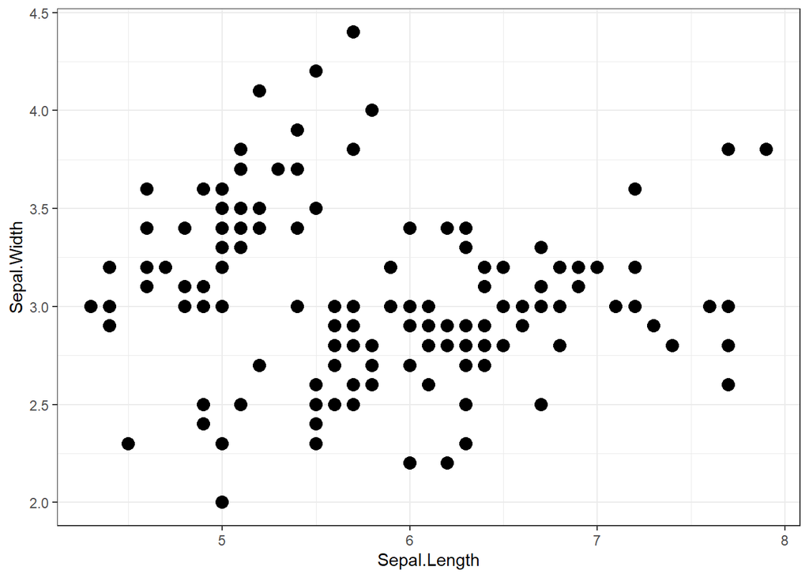

```r
iris %>%
  ggplot(mapping = aes(x = Sepal.Length, y = Sepal.Width)) +
  geom_point(size = 3.5) +
  theme_bw()
```

Transparency can help identify “high density” regions.

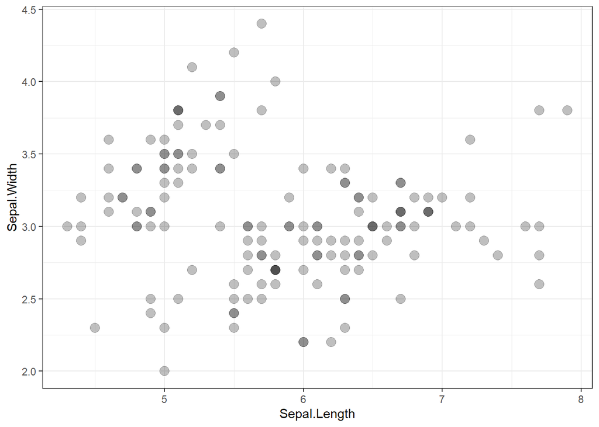

```r
iris %>%
  ggplot(mapping = aes(x = Sepal.Length, y = Sepal.Width)) +
  geom_point(size = 3.5, alpha=0.25) +
  theme_bw()
```

Or we can count the number of observations per combination.

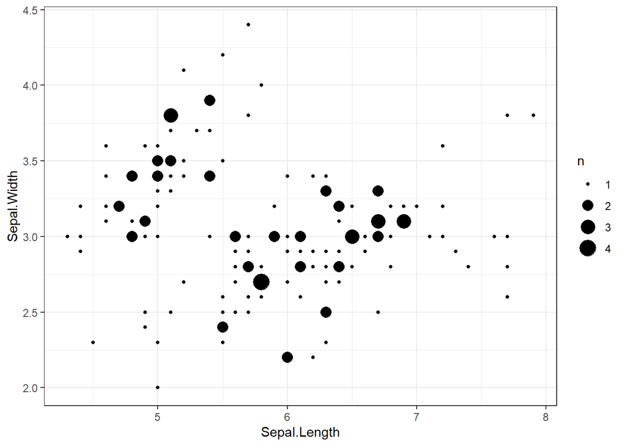

```r
iris %>%
  ggplot(mapping = aes(x = Sepal.Length, y = Sepal.Width)) +
  geom_count() +
  theme_bw()
```

But what if we have more data? Or what there are many tightly packed observations, but a large number of unique values?

For example, let’s work with the `diamonds` data set.

```r
diamonds %>% dplyr::glimpse()
```

```
## Rows: 53,940
## Columns: 10
## $ carat   <dbl> 0.23, 0.21, 0.23, 0.29, 0.31, 0.24, 0.24, 0.26, 0.22, 0.23, 0.~
## $ cut     <ord> Ideal, Premium, Good, Premium, Good, Very Good, Very Good, Ver~
## $ color   <ord> E, E, E, I, J, J, I, H, E, H, J, J, F, J, E, E, I, J, J, J, I,~
## $ clarity <ord> SI2, SI1, VS1, VS2, SI2, VVS2, VVS1, SI1, VS2, VS1, SI1, VS1, ~
## $ depth   <dbl> 61.5, 59.8, 56.9, 62.4, 63.3, 62.8, 62.3, 61.9, 65.1, 59.4, 64~
## $ table   <dbl> 55, 61, 65, 58, 58, 57, 57, 55, 61, 61, 55, 56, 61, 54, 62, 58~
## $ price   <int> 326, 326, 327, 334, 335, 336, 336, 337, 337, 338, 339, 340, 34~
## $ x       <dbl> 3.95, 3.89, 4.05, 4.20, 4.34, 3.94, 3.95, 4.07, 3.87, 4.00, 4.~
## $ y       <dbl> 3.98, 3.84, 4.07, 4.23, 4.35, 3.96, 3.98, 4.11, 3.78, 4.05, 4.~
## $ z       <dbl> 2.43, 2.31, 2.31, 2.63, 2.75, 2.48, 2.47, 2.53, 2.49, 2.39, 2.~
```

Look at the scatter plot between `price` and `carat`.

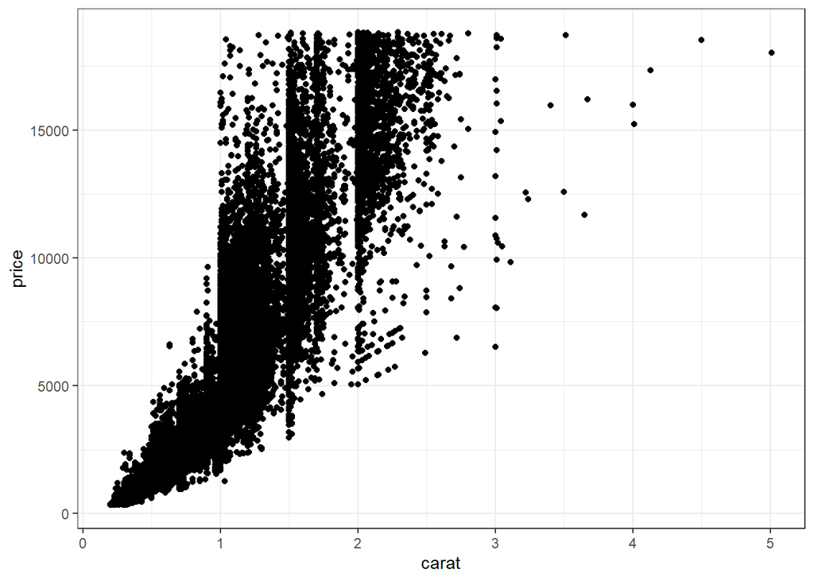

```r
diamonds %>%
  ggplot(mapping = aes(x = carat, y = price)) +
  geom_point() +
  theme_bw()
```

Raise transparency (reduce `alpha`).

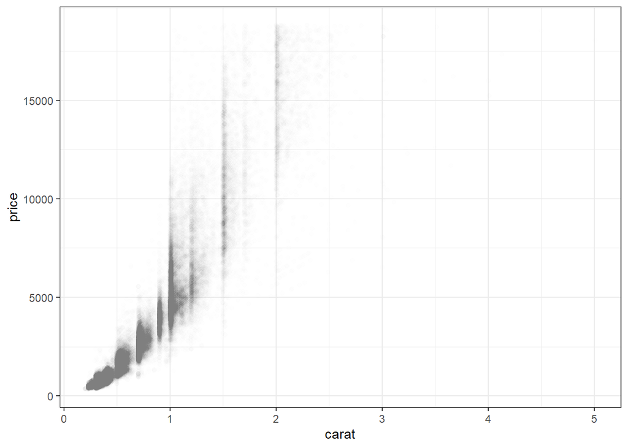

```r
diamonds %>%
  ggplot(mapping = aes(x = carat, y = price)) +
  geom_point(alpha = 0.005) +
  theme_bw()
```

If we count…we can’t really see anything…

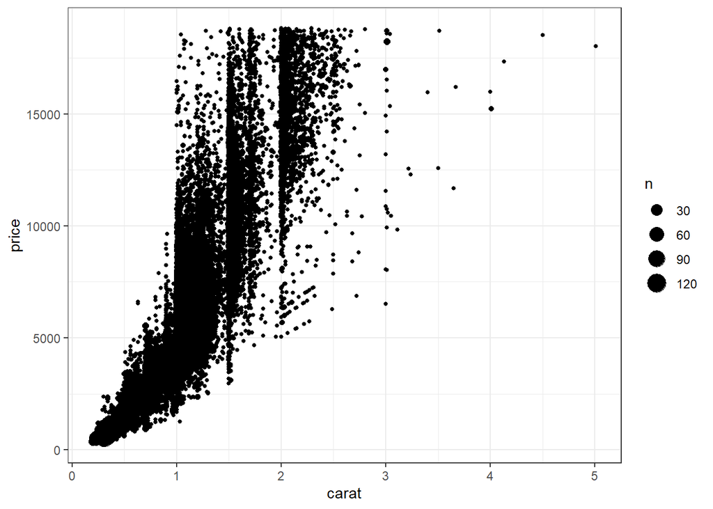

```r
diamonds %>%
  ggplot(mapping = aes(x = carat, y = price)) +
  geom_count() +
  theme_bw()
```

We want to know where the data are dense vs less concentrated. We can use 2D histogram to represent the **joint distribution** between two continuous variables.

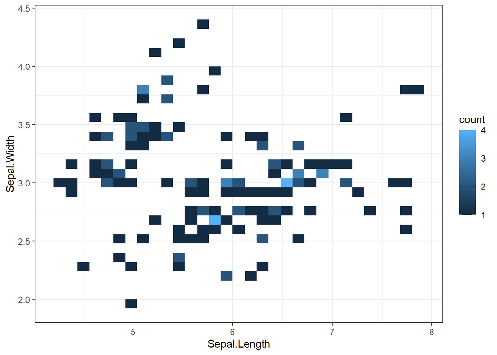

```r
iris %>%
  ggplot(mapping = aes(x = Sepal.Length, y = Sepal.Width)) +
  geom_bin_2d() +
  theme_bw()
```

Essentially `geom_bin_2d()` performs two `cut()` functions behind the scenes and then `count()` by the combinations of the discretized continuous variables.

We can raise or lower the number of bins.

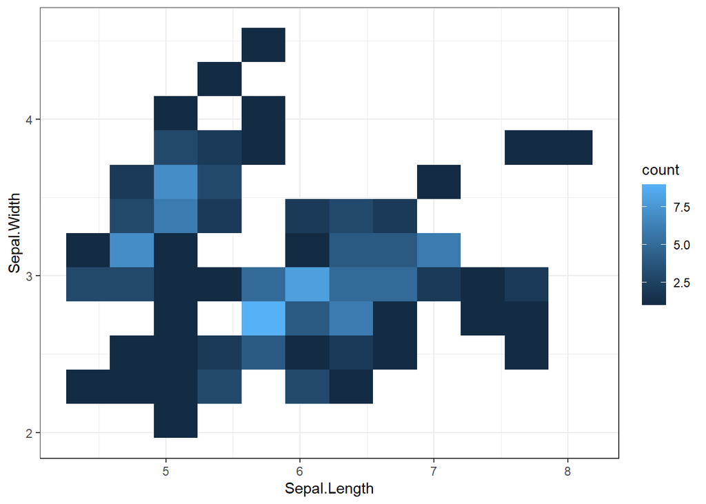

```r
iris %>%
  ggplot(mapping = aes(x = Sepal.Length, y = Sepal.Width)) +
  geom_bin_2d(bins = 11) +
  theme_bw()
```

Because the bin is defined based on 2 variables we can use two separate bin sizes.

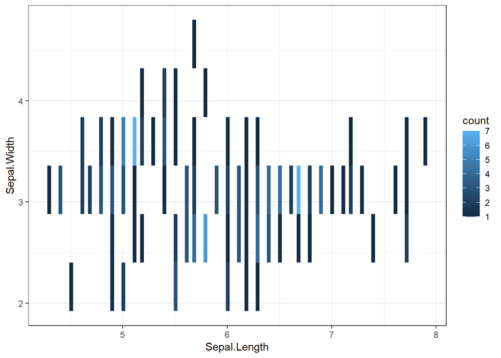

```r
iris %>%
  ggplot(mapping = aes(x = Sepal.Length, y = Sepal.Width)) +
  geom_bin_2d(bins = c(101, 5)) +
  theme_bw()
```

I tend to start with 11 bins in each direction.

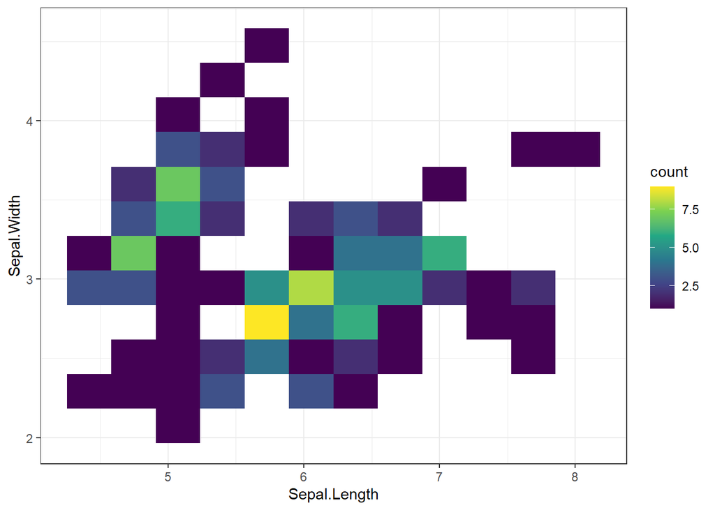

```r
iris %>%
  ggplot(mapping = aes(x = Sepal.Length, y = Sepal.Width)) +
  geom_bin_2d(bins = 11) +
  scale_fill_viridis_c() +
  theme_bw()
```

Let’s now make a 2D histogram for the `price` and `carat` joint distribution.

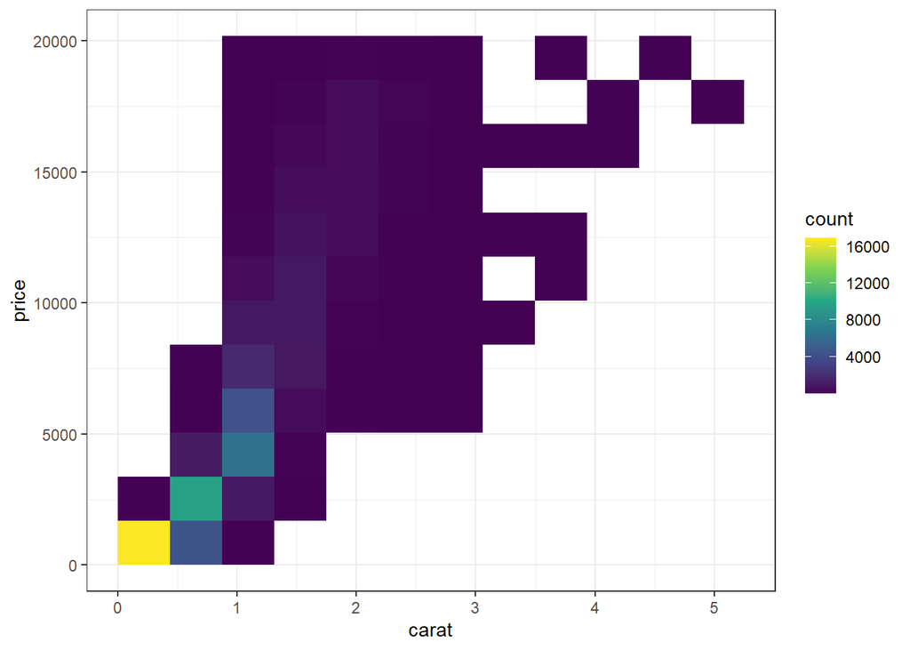

```r
diamonds %>%
  ggplot(mapping = aes(x = carat, y = price)) +
  geom_bin_2d(bins = 11) +
  scale_fill_viridis_c() +
  theme_bw()
```

Try the default number of bins.

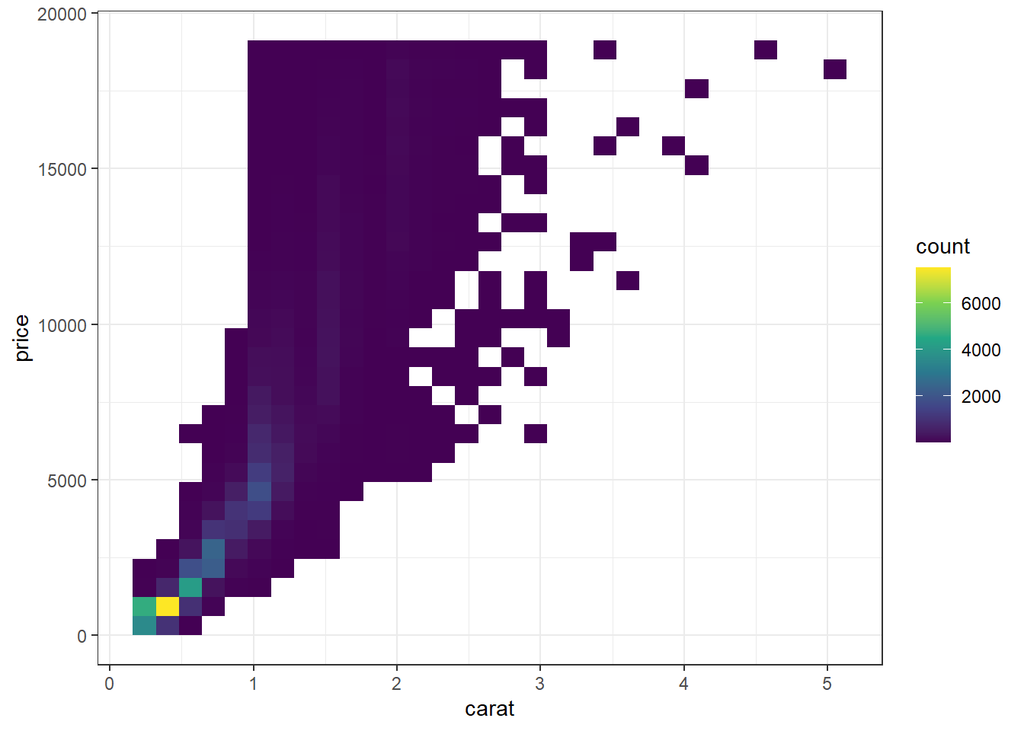

```r
diamonds %>%
  ggplot(mapping = aes(x = carat, y = price)) +
  geom_bin_2d() +
  scale_fill_viridis_c() +
  theme_bw()
```

Alternatively instead of the rectangles we can use hexagons to represent the 2D histogram.

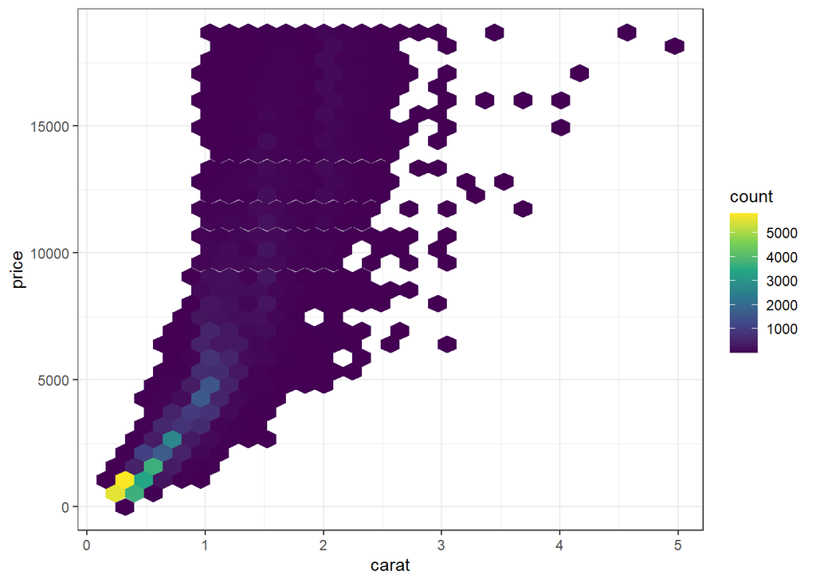

```r
diamonds %>%
  ggplot(mapping = aes(x = carat, y = price)) +
  geom_hex() +
  scale_fill_viridis_c() +
  theme_bw()
```